```python
import matplotlib.pyplot as plt
import seaborn as sns
import pandas as pd
import missingno as msno
import numpy as np

sns.set_context("notebook", font_scale = 1.5, rc = {"lines.linewidth" : 2})
%matplotlib inline

import warnings
warnings.filterwarnings(action='ignore')
from IPython.core.display import display, HTML
display(HTML("<style>.container { width:80% !important; }</style>"))
```

# Understanding The Websoccer

When examining the influence tactics have on the game simulation, it is necessary to understand how game simulation *really* works.  
There are 3 types of actions that can happen: a pass, a shot, or a tackle.  
On top of that is a decider - a *Football God* - who determines the next action in the game.

So let us look into how the Football God decides which action will take place next.

# The Football God

Firstly, if your Goalkeeper has the ball, the only thing he can do is to pass it to one of his teammates.

But what about the field players?

## Tackle

The probability of a tackle depends on the formation of both teams. Let us say the player who is currently holding the ball is a midfielder. Then the probability of getting tackled depends on how many midfielders the opposition has.

**Code alert**

$p_{tackle} = \begin{cases} 20 + 20 (N_{opponent}^{midfield} - N_{ballholding}^{midfield}) & \text{, other team has more midfielders} \\ 40 & \text{, else} \\ \end{cases}$

**\Code alert**

So basically the probability of a tackle is most of the time $40\%$, but if the other team has 2 more players in the respective part of the field, it is $60\%$, if they have 3 more, it is $80\%$.

## Shooting

The probability of getting a shot depends on three variables: the position of the ball-holding player, the tactics, and the current result. Furthermore, the probability of getting a shot can not be higher than $50\%$.

Let us disentangle this: Which influence have these three variables?

### Current Result

This is really straightforward: If you have less goals than the other team, your team is $10\%$ more likely to shoot.

### Position of the Shooter

Defenders have a $5\%$ chance of shooting, Midfielders $20\%$ and Strikers $35\%$.  
BUT: if you play with counter-attacks, these values are *halved*.

### Tactics

This depends only on your offensive strength and the opponent's defensive strength and is simply calculated: Off_strength(Ball-holding) - Def_strength (opponent).

That is the point where it stops being simple.  
Because.. what the heck is offensive and defensive strength? We will take a closer look on that soon.

## Passing

If none of the other two actions happen, players simply pass the ball. If long passes are activated, the passing attempt fails $30\%$ more often. NOTE: As there is a bug in the underlying code, long passes have **NO positive effect**.  
If counter attacks are activated, there is a change of Offensive_Setting$\%$ to get a shot after the opposition striker's passing attempt failed.

So okay, it got a little bit more clear what is going on in the Football God's mind. But we still have to understand at least one thing: What the heck are offensive and defensive strength?

# Offensive and Defensive Strength

... it is complicated. If you want to look at the code, you will understand the exact definition easily. But for all the others, this explanation needs to be sufficient:

*Offensive Strength* is the strength of your midfielders and strikers  
*Defensive Strength* is the strength of your midfielders and defenders

$\Rightarrow$ having a strong midfield will yield success, as it is strengthens both your offense and defense

In the following, I wrote a small testing program to evaluate the strength of different possible tactics.  
NOTE: For sake of simplicity, all players have strength 100.

Explanation of Formation-Arrays: [Defenders,DM,Midfielders,OM,Strikers]

```python
offensive_setting_array = np.linspace(0,100,101,endpoint = True)
# default strength for all players in all formations
strength = 100
```

```python
'''
Definitions of Offensive and Defensive Strength
 - formation is given as list - example: [4,1,3,1,1]
 - off: offensive setting
'''

def offensive_strength(formation,off):
    off_fac = (80+off*0.4)/100
    mf_st = formation["DM"]*0.7*strength + formation["MF"]*strength + formation["OM"]*1.3*strength
    st_st = 0
    if formation["ST"] < 3:
        st_st = formation["ST"]*1.5*strength
    elif formation["ST"] == 3:
        st_st = 2*1.5*strength + 0.5*strength
    elif formation["ST"] == 4:
        st_st = 2*1.5*strength + 2*0.5*strength
    off_st = off_fac*(mf_st+st_st)
    return int(off_st)

def defensive_strength(formation,off):
    def_fac = (130-off*0.5)/100
    mf_st = formation["DM"]*1.3*strength + formation["MF"]*strength + formation["OM"]*0.7*strength
    df_st = 0
    if formation["DF"] < 3:
        df_st = 0.5*formation["DF"]*strength
    elif formation["DF"] > 4:
        df_st = 1.5*formation["DF"]*strength
    else:
        df_st = formation["DF"]*strength
    def_st = def_fac*(mf_st+df_st)
    return int(def_st)
```

```python
'''
Definitions of an example formation (for testing purposes)
and the "common opposite"-formation
'''

formation_ex = {
    "DF": 4,
    "DM": 1,
    "MF": 3,
    "OM": 1,
    "ST": 1,
}
formation_opp = {
    "DF": 4,
    "DM": 1,
    "MF": 3,
    "OM": 1,
    "ST": 1,
}
```

```python
# calculate the values for "common opposite"-formation with an offensive setting of 20
opposition = defensive_strength(formation_opp,20)/10, offensive_strength(formation_opp,20)/10
opposition[0]
```

```
108.0
```

```
Formation:	[4, 1, 3, 1, 1]
```

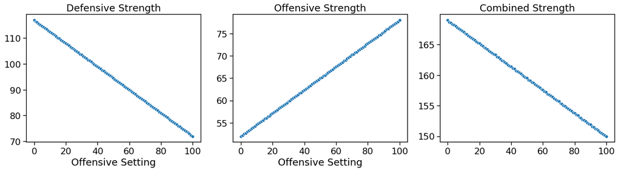

```python
def_arr = np.array([])
off_arr = np.array([])
comb_arr = np.array([])

for off in offensive_setting_array:
    def_arr = np.append(def_arr,defensive_strength(formation_ex,off)/10)
    off_arr = np.append(off_arr,offensive_strength(formation_ex,off)/10)
    comb_arr = np.append(comb_arr,(offensive_strength(formation_ex,off)+defensive_strength(formation_ex,off))/10)

form_a=np.array([])
for key,val in formation_ex.items():
        form_a = np.append(form_a,val)
print(f"Formation:\t{list(map(int, form_a))}")

f, ax = plt.subplots(1, 3, figsize = (16,4))
f.tight_layout()
sns.scatterplot(y = def_arr,x = offensive_setting_array, ax = ax[0])
ax[0].set(xlabel='Offensive Setting', title='Defensive Strength')
sns.scatterplot(y = off_arr,x = offensive_setting_array, ax = ax[1])
ax[1].set(xlabel='Offensive Setting', title='Offensive Strength')
sns.scatterplot(y = comb_arr,x = offensive_setting_array, ax = ax[2])
ax[2].set(title='Combined Strength')
plt.show()
#f.savefig('off_setting.png', bbox_inches='tight')
```

$\Rightarrow$ linear relation of offensive setting in defensive and offensive strength  
$\Rightarrow$ with the offensive setting, every tactics used can be tuned into being offensive or defensive

- note that the range of defensive strength is nearly twice as high as for the offensive strenght $\Rightarrow$ for every offensive strenth point gained, you lose two defensive strength points
- even though the exact numbers are different for other formations, these patterns are ubiquitous

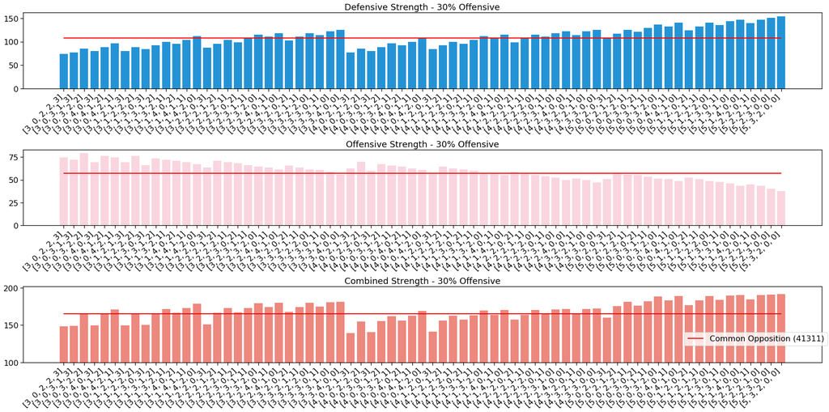

```python
for offensiv in [30]:# 1,25,50,75,100]:

    import itertools
    # VT,DM,CM,OM,ST
    iterables = [[3,4,5],
                 np.linspace(0,3,4, endpoint=True, dtype = int),
                 np.linspace(2,4,3, endpoint=True, dtype = int),
                 np.linspace(0,2,3, endpoint=True, dtype = int),
                 np.linspace(0,3,4, endpoint=True, dtype = int)]

    formation_arr = np.array([])
    offf_arr = np.array([])
    deff_arr = np.array([])
    combb_arr = np.array([])

    for t in itertools.product(*iterables):
        if sum(list(t)) == 10:
            formation_it = {
                "DF": list(t)[0],
                "DM": list(t)[1],
                "MF": list(t)[2],
                "OM": list(t)[3],
                "ST": list(t)[4],
            }
            formation_arr = np.append(formation_arr,str(list(t)))
            combb_arr = np.append(combb_arr,(offensive_strength(formation_it,offensiv)+defensive_strength(formation_it,offensiv))/10)
            deff_arr = np.append(deff_arr,defensive_strength(formation_it,offensiv)/10)
            offf_arr = np.append(offf_arr,offensive_strength(formation_it,offensiv)/10)


    f, ax = plt.subplots(3, 1, figsize = (24,12))
    chart = sns.barplot(formation_arr,deff_arr,ax = ax[0],color='xkcd:azure')
    chart.set(title=f'Defensive Strength - {offensiv}% Offensive')
#     ax[0].hlines(np.mean(deff_arr),0,len(formation_arr)-1)
    ax[0].hlines(opposition[0],0,len(formation_arr)-1,color="red")
    chart.set_xticklabels(chart.get_xticklabels(), rotation=45,horizontalalignment='right')

    chart = sns.barplot(formation_arr,offf_arr,ax = ax[1],color='xkcd:pale pink')
    chart.set(title=f'Offensive Strength - {offensiv}% Offensive')
#     ax[1].hlines(np.mean(offf_arr),0,len(formation_arr)-1)
    ax[1].hlines(opposition[1],0,len(formation_arr)-1,color="red")
    chart.set_xticklabels(chart.get_xticklabels(), rotation=45,horizontalalignment='right')

    chart = sns.barplot(formation_arr,combb_arr,ax = ax[2],color='xkcd:salmon')
    chart.set(title=f'Combined Strength - {offensiv}% Offensive')
#     ax[2].hlines(np.mean(combb_arr),0,len(formation_arr)-1,label="Mean Value")
    ax[2].hlines(sum(opposition),0,len(formation_arr)-1,color="red",label="Common Opposition (41311)")
    chart.set_xticklabels(chart.get_xticklabels(), rotation=45,horizontalalignment='right')
    chart.set_ylim(100,np.max(combb_arr)+10)
    f.tight_layout()
    f.legend(loc='lower right',bbox_to_anchor=(1, 0.15))
    #f.savefig(f'formation_{offensiv}off.png', bbox_inches='tight')
```

```python
np.linspace(0,3,4,endpoint=True,dtype = int)
```

```
array([0, 1, 2, 3])
```

- combined strength = defensive + offensive strenght
- note that combined strength is cut off at 100, not at 0
- counter-attacks (not in the graphics) increase defensive strength a small amount (educated guess: max. 5 percent)

$\Rightarrow$ formations in the middle are usually more balanced  
$\Rightarrow$ the more right, the more defensive, the more left, the more offensive  
$\Rightarrow$ formations with 3 strikers do not yield a big strength (due to a penalty for the third striker, which effectively plays with 50% strength) $\Rightarrow$ either use 3 or 5 defenders, not 4